# Beyond the Summary

How to Plan, Structure, and Place a High-Impact Review Article

Soorathep Kheawhom, PhD, FRSC

Department of Chemical Engineering, Faculty of Engineering  
Center of Excellence on Advanced Materials for Energy Storage  
Chulalongkorn University, Bangkok, Thailand

9 September 2026

## The two numbers

Why this session exists

Average

2.95×

Citation multiplier of a review over an original research article, across all fields. Range 1.34× to 6.74× by discipline.

Reality

21%

Share of 538 reviews published in one field that had passed ten citations two years later. The other 79% had ten citations or fewer at that point.

Miranda & García-Carpintero, *J. Informetr.* **12**, 1015 (2018) · Ketcham & Crawford, *Lab. Invest.* **87**, 1174 (2007)

## Five questions

Today

- 20 min What kinds of review exist, and which one is mine?
- 6 min What does a review do to my academic profile?
- 16 min What are research gaps, and what makes a review novel?
- 28 min PRISMA → evidence matrix → synthesis → research gaps
- 18 min What does the finished paper look like, down to the title?

## Part 1 · The genre map

Ten different things are called a review. This part ends with a three-question test that tells you which one is yours.

## “Review” is a journal label, not a method

Part 1

What the journal calls it

Review · Critical Review · Tutorial Review · Minireview · Focus · Perspective · Survey · Roadmap · Opinion · Viewpoint

What you actually have to do

Narrative · Systematic · Scoping · Mapping · Critical · Integrative · Meta-analysis · Umbrella · Rapid

Choose the method first, then find a venue whose format fits it. Never the reverse.

## What a review article actually is

Part 1

If you have never written one, start by looking at the object, not at the definition.

1. **New experiments are not required.** A review synthesises existing evidence; it can create a new coded dataset, an effect estimate, a framework or a justified research agenda.
2. **Figures communicate the synthesis.** Conceptual diagrams, evidence maps and quantitative plots can show relationships that individual studies do not make visible. Plan them early.
3. **The structure should reveal the contribution.** Organise sections around the review question and synthesis. Novelty lies in what readers can understand or conclude, beyond the closest reviews.

## Three things that get taught wrong

Part 1

Myth

**“A systematic review is better than a critical review.”**

Systematic describes how the evidence was found. It buys transparency and reproducibility. It does not buy insight.

Myth

**“Meta-analysis is the highest level of review.”**

It is a statistical step used inside a systematic review when outcomes are commensurable. Not a rung above anything.

Myth

**“A critical review is just an unsystematic review.”**

Its value is the reasoning: testing assumptions, locating contradictions, separating correlation from mechanism.

Being systematic tells you how reliably the literature was collected. Being critical tells you what new understanding was created from it.

## SALSA: the four dials behind every review type

Part 1

S

### Search

How much of the literature did you look for, and can someone repeat it?

A

### Appraisal

Did you judge the quality of what you found, or accept every paper equally?

S

### Synthesis

How did you bring the studies together: narrative, tabular, or statistical?

A

### Analysis

What new understanding did you produce that no single paper contains? Make this step explicit: connect the synthesis to what readers can now understand or do.

Grant & Booth, *Health Info. Libr. J.* **26**, 91 (2009); extended to 48 review types by Sutton et al., *ibid.* **36**, 202 (2019)

## One topic, four completely different papers

Part 1

Same literature, same author. The type is a decision about which question you are answering.

Narrative

*“Artificial Interphases for Aqueous Zinc Anodes: Progress and Prospects”*

**Answers:** what has the field been doing?

Scoping

*“Mapping the Evidence for Artificial Interphases on Zinc Anodes: What Is Measured, and What Is Not”*

**Answers:** what evidence exists, and where are the holes?

Critical

*“Cycling Stability of Coated Zinc Anodes Is Set by Test Conditions, Not by Coating Chemistry”*

**Answers:** is the field’s central claim actually supported?

Systematic + meta

*“Do Artificial Interphases Extend Zinc Anode Life? A Systematic Review and Conditional Meta-Analysis”*

**Answers:** how large is the effect, and under which conditions?

None of these is more advanced than the others. They answer different questions and they fail in different ways.

## Five types built around evidence

Part 1

1. **Narrative** — *“I have read this field for years, and here is what I think matters.”* Selection is less standardised; describe the basis and limits of the claims.
2. **Systematic** — *“I searched by a written protocol, and here is everything that met my criteria.”* Six to twelve months, two people minimum.
3. **Scoping** — *“Here is the shape of the evidence, and here are the holes in it.”* High search, low appraisal. A realistic first review.
4. **Mapping** — *“Here is a classification of the field, usually with a database others can search.”* The output is the map itself.
5. **Meta-analysis**, a method and not a type — *“Inside a systematic review: I pooled the numbers into one effect size.”* Only possible when outcomes are commensurable.

Narrative versus systematic is not a ranking of quality. The method determines which claims the evidence can support.

## Five types built around an argument

Part 1

1. **Critical** — *“The field believes X. I will show you why that is only partly right, and what to believe instead.”* The argument is the work.
2. **State-of-the-art** — *“Here is what is actually known now, covering the last five to ten years completely.”*
3. **Tutorial** — *“Here is how this method really works, explained for someone who has never used it.”* Clarity outranks completeness.
4. **Perspective / Opinion** — *“Here is where I think this field should go next.”* Little writing, but it trades on reputation. Almost always invited.
5. **Umbrella** — *“Six reviews on this topic disagree. Here is what they collectively show.”*

Realistic first review, with a senior co-author: a scoping review, a critical review, or a tutorial review.

## Two axes, not a ladder

Part 1

Low systematic · high critical

### Critical review

Insight, no documented search

High systematic · high critical

### Systematic critical review

Documented search, then real synthesis. A useful combination when the question needs both transparent selection and critical interpretation.

Low · low

### Narrative review

Expert commentary, no protocol

High systematic · low critical

### Descriptive systematic review

Rigorous search, thin synthesis

## Do not import the clinical evidence hierarchy

Part 1

Clinical / medical

- *“Does treatment A improve outcome B compared with C?”*
- Population and dose vary, inside a largely shared protocol
- The unit compared is a pre-defined clinical outcome
- Synthesis narrows the uncertainty around an effect
- **Pooling is often meaningful**

Materials / engineering

- *“Why does this system behave this way, when does it work, and when does it fail?”*
- Loading, current density, cell format, electrolyte, cut-off criterion. Effectively everything varies
- The unit compared is a number whose test conditions differ study by study
- Synthesis produces a **mechanism** that explains why results diverge
- **Pooling is sometimes precise and physically meaningless**

The right review methodology is set by the scientific question, not by a hierarchy borrowed from another discipline.

## So which one should you write?

Part 1

1 Can you state a claim about your field that an expert would argue with? No, not yet → go to 2. This is the normal starting position, not a failure. Yes → go to 3.

2 Is your goal to map what exists and find the gaps? Yes → scoping or mapping review. The right first review: defensible, useful, and it tells you whether a critical review is possible later. No → narrative review, fine as a thesis chapter or grant background.

3 Are the outcomes comparable enough to pool or normalise? No → critical review. Add a documented search and it becomes a systematic critical review. Yes → systematic review, with a meta-analysis only if pooling survives scrutiny.

Three questions, four honest answers. None of them is “write the most comprehensive review you can”.

## Part 2 · Your academic profile

The honest version: what it buys you, what it costs the field, and what it will not do for your promotion case.

## Reviews are over-represented at the top

Part 2

1. Among the top 0.05–0.1% most-cited papers, the review share rose from roughly **17% in 1990 to about 40% in 2010**.
2. Reviews count as citable items in the impact-factor denominator, exactly like research papers, so a review-heavy portfolio raises a journal’s IF mechanically. Seven of the ten highest-IF journals in the 2025 JCR are review journals.
3. The multiplier is largest in fields where reviews are rarest. **In review-saturated fields the premium collapses.**

The premium is real, and it is strategic: it is largest exactly where nobody has reviewed yet.

Miranda & García-Carpintero, *J. Informetr.* **12**, 1015 (2018); the 1990 share is reported there as 16–18% · 2025 Journal Citation Reports

## The other side of the ledger

Part 2

**38%** — median reduction in future citations to a primary paper after a review covers it. About 70% of reviewed papers lose citations. Analysis of ~6 million articles, 1990–2016.

1. **Your review absorbs credit that belonged to other people.** Cite the specific primary paper for a specific claim; cite the review only for context.
2. **Referees are increasingly hostile to reviews with no contribution.** Editors in energy and materials now publish editorials asking authors to stop writing unnecessary reviews.
3. **Volume has consequences.** Systematic reviews grew 2,728% between 1991 and 2014; roughly a third were judged redundant.

McMahan & McFarland, *Am. Sociol. Rev.* **86**, 341 (2021) · Ioannidis, *Milbank Q.* **94**, 485 (2016) · Kamat, Christopher & Jin, *ACS Energy Lett.* **10**, 5020 (2025)

## What a review genuinely buys you

Part 2

1. **Agenda setting.** You decide which papers become the canon of your subfield. The largest and least-discussed benefit.
2. **A research identity.** A review is where you name and defend the framework your group works under.
3. **Invitation flow.** Editors commission people who have already written well on the topic. The first review is what makes the second one an invitation.
4. **Reusable infrastructure.** Grant proposal backgrounds, a course module, and the fastest way to onboard a new student.
5. **Low-risk collaboration.** A multi-institution review often precedes a joint experimental project.

## What a review will not do for you

Part 2

### Not a substitute for primary research

A record heavy on reviews and thin on experimental papers reads as a group without a working laboratory.

### Not a substitute for expertise

Referees notice reviews assembled from abstracts, and abstract-only reading propagates other people’s errors under your name.

### Not faster than a research paper

Six to twelve months, 100+ references, plus revision rounds.

**The pattern that works for early-career authors:** junior first author, senior sponsor. A study of 1,102 reviews found junior researchers were the predominant authors and served mainly as first authors. You are senior enough to be first author. You are probably not senior enough to be sole author.

Chang & Wu, *Scientometrics* **130**, 4995 (2025) — carried out in library and information science, so indicative rather than proven for engineering

## Part 3 · Go / No-Go

Five gates, the contribution ladder, and the question everyone asks: what am I contributing if I have no new data?

## Gate 1 and Gate 2: is the field ready, and is it taken?

Part 3

Gate 1 · Field maturity

- **30+** relevant primary papers in the last 2–3 years means the topic is timely
- **15–20** within the last 5 years is the absolute minimum
- **< 50** significant papers overall and the topic is probably too immature
- **> 120** and your scope is too broad. Narrow it, or split the paper

Gate 2 · Review saturation

The editorial rule at *Chemical Reviews*: the topic must not have been comprehensively reviewed in the past **3 to 4 years**. Every RSC proposal form asks you to justify why there is room for another.

**Run the review search before the primary search.** In Scopus: your terms `AND DOCTYPE(re) AND PUBYEAR > 2020`, then repeat with `DOCTYPE(ar)` for the last three years.

Those two counts give you Gate 1 and Gate 2 in fifteen minutes.

## Gates 3 to 5: standing, thesis, capacity

Part 3

3 Standing Do you have primary research papers on this topic from the last three years? RSC and ACS proposal forms require them by DOI. If not, your route is a co-authored review with someone who has them.

4 A thesis Can you state, in one sentence, a claim an expert would argue with? “Advances in X” is not a thesis. “The reported cycle-life gains in X are an artefact of test protocol, not of materials chemistry” is a thesis.

5 Capacity Six to twelve months, a co-author, and a student who will not be derailed. A review is a project, not a gap-filler between experiments.

## The contribution ladder

Part 3

A guide to contributions in a critical review. Useful evidence maps and classifications can also contribute.

1. **Collection** — *“What papers exist on this topic?”*
2. **Classification** — *“How can they be grouped?”*
3. **Comparison** — *“How do they differ from one another?”*
4. **Synthesis** — *“What does the evidence collectively say?”*
5. **Critique** — *“What is unreliable, inconsistent or missing?”*
6. **Reconciliation** — *“Why do these studies appear to disagree?”*
7. **Framework or mechanism** — *“Can one concept account for all of it?”*
8. **Design rules and hypotheses** — *“What should we build or test next?”*

The contribution test: what does this review let readers understand or do? Match the contribution to the question, then compare it with prior syntheses.

## What counts as novelty in a review?

Part 3

Novelty is a useful advance in understanding, justified against prior reviews.

### A taxonomy or framework

You justify categories or relationships that make the evidence easier to explain and use.

### An evidence standard

You justify appraisal criteria and show how evidence quality changes the conclusions.

### A reconciliation

You explain why two bodies of literature that disagree both appear to be right.

### A quantitative synthesis

You estimate an effect when outcomes and conditions support a valid comparison.

### A negative finding about the field

You show that a widely believed claim rests on very thin evidence.

### A justified research gap

You show what remains uncertain, why it matters and what evidence could resolve it.

## Research gap, review gap and novelty

Part 3 · Three different questions

| Term | Meaning | Question to answer |
| --- | --- | --- |
| **Research gap** | An important question that available evidence cannot yet answer adequately. | What remains uncertain, and why does it matter? |
| **Review gap** | A question or perspective that prior reviews have not adequately synthesised. | What did previous syntheses leave unresolved? |
| **Review novelty** | New, useful and justified understanding relative to previous reviews. | What can readers now understand or conclude? |

A defensible gap statement

Within **[scope]**, evidence leaves **[question]** uncertain because **[reason]**. This matters for **[decision]** and calls for **[specific test]**.

Teaching definitions informed by [AHRQ: Identifying Research Gaps](https://www.ncbi.nlm.nih.gov/books/NBK62472/?report=classic) and [Webster & Watson (2002)](https://misq.umn.edu/skin/frontend/default/misq/pdf/TheoryReview/GuestEd.pdf).

## Exercise 1 · Your gap and planned contribution

Research gap · 5 minutes total

State what remains uncertain, why the evidence is inadequate and why the question matters.

Review novelty

State what your synthesis will add beyond the three closest reviews.

Treat both statements as provisional. Verify them against the evidence matrix and your prior-review comparison table.

## Part 4 · The process

Eight steps from idea to submission, and where AI tools legitimately fit into them.

## Eight steps, and where the time actually goes

Part 4

1. **Scope** — define the question with PCC: Population, Concept, Context. Write down what is excluded and which years you cover.
2. **Prior-review gap** — build the prior-review comparison table first.
3. **Proposal** — two to five pages to the editor before you write anything.
4. **Search** — multi-database, documented, validated against a seed set.
5. **Screen and extract** — two screeners, a written inclusion rule, one template.
6. **Appraise** — grade the evidence. This is where reviews win.
7. **Synthesise** — evidence matrix → concepts → candidate research gaps.
8. **Write** — figures first, then the prose around them.

Steps 2, 3 and 6 are the ones beginners skip, and they are the three that decide whether the review is publishable. Steps 1 to 3 take about a month and cost almost nothing.

## Step 2 · The prior-review comparison table

Part 4

Build this before you write anything else. It is the artefact that gets a proposal accepted.

1. **Prior review** — author, year, journal. One row each.
2. **Window** — the years it covered.
3. **Organising logic** — materials-by-materials, application-driven, bibliometric, and so on.
4. **What it does not do** — the specific omission, not a vague complaint.
5. **What we add** — the column that matters.

### Three things this table does

It answers the mandatory question on every RSC and ACS proposal form. It becomes a real table in the published introduction, and readers cite tables like this. And it tells you honestly whether column 5 is empty.

### If column 5 is empty

Reconsider the question or scope. An update needs to explain how new evidence changes understanding, conclusions or confidence.

## Step 3 · The proposal

Part 4

At *Chemical Reviews*, a manuscript sent without an invitation or an approved proposal is not reviewed. It is returned.

Chemical Reviews (ACS) · max 5 pages

Title, authors and affiliations · a detailed topical outline of 2–3 pages · a list of previous reviews · five closely related papers by the authors · estimated reference and page count · tentative submission date · at least five suggested referees

RSC journals · under 2 pages

Proposed title, authors, submission date · why the field matters now · comments on other reviews on a similar topic, justifying why there is room for another · section outline with ten or more core references with DOIs · a CV of three pages or less highlighting your last-three-years papers

## Step 4 · The search: reproducible, or it does not count

Part 4

Databases, in this order

Scopus and Web of Science Core Collection as the two primary systems · Engineering Village (Compendex + Inspec) for the only real controlled vocabulary in engineering · **Google Scholar as a supplement only** — not reproducible, unsuitable as a principal search system

Record this, per database

Platform and interface · the full search string verbatim · the date you ran it and the coverage years · every filter · number of records retrieved · who designed and who checked the string · forward and backward citation chasing as a separate arm · deduplication counts before and after

Validate before you screen: pick 10 to 30 papers you already know must be included. If your string misses any of them, the string is not finished.

PRISMA 2020 and PRISMA-S: prisma-statement.org · Gusenbauer & Haddaway, *Res. Synth. Methods* **11**, 181 (2020)

## PRISMA: reporting the selection process

Part 4 · Search and selection

PRISMA 2020 combines a reporting checklist with a flow diagram.

[figure not shown]

Working records to keep

Search strings, dates and counts

Eligibility rules and screening decisions

Full-text exclusion reasons

Links between reports of one study

Choose the matching guidance

Systematic review: PRISMA 2020  
Scoping review: PRISMA-ScR  
Search reporting: PRISMA-S

Reporting transparency does not certify study quality or supply the review’s novelty.

[PRISMA 2020](https://journals.plos.org/plosmedicine/article?id=10.1371/journal.pmed.1003583) · [PRISMA-ScR](https://www.prisma-statement.org/scoping) · [PRISMA-S](https://www.prisma-statement.org/prisma-search)

## Step 5 · Screening and extraction

Part 4

1. **Rayyan** — free tier, fast blinded dual screening. Weaker deduplication than Covidence; opaque AI ranking.
2. **Covidence** — end-to-end: dedupe, screen, extract, PRISMA diagram. Paid; check for a university licence.
3. **ASReview** — free and open source; active learning ranks likely-relevant records first. Prioritisation is not exclusion, and you must justify when you stopped.
4. **Elicit and similar LLM tools** — a second extractor for factual fields. Accuracy collapses on interpretive fields.
5. **Connected Papers, ResearchRabbit, Litmaps** — orientation and checking that your string missed no cluster. Not reproducible, so not a search arm.
6. **Zotero / EndNote** — reference management and deduplication. No blinded dual screening, so not a screening system of record.

**Design the extraction template from your framework, not from the papers.** Decide what every included study must tell you before you open the first PDF.

## AI tools: where they legitimately help

Part 4 · Step 5b

1. **Scoping and gaps** — Connected Papers, ResearchRabbit, Litmaps surface clusters your string missed. *Never report them as a search arm: not reproducible.*
2. **Search strings** — litsearchr, or an LLM for synonyms and legacy terms. *Never skip the seed-set recall check.*
3. **Screening** — ASReview, Rayyan ranking, an LLM pre-filter can rank records or act as a declared second screener. *Never the sole screener. Humans adjudicate every disagreement.*
4. **Data extraction** — Elicit, Covidence suggestions pre-fill factual fields. *Never interpretive fields: accuracy collapses there.*
5. **Claim checking** — Scite citation statements and retraction flags show whether a claim is contested. *Never accept it without reading the source.*
6. **Language** — any general LLM can improve the clarity of sentences you wrote. *Never generate synthesis prose or citations.*

### The three-line ethical test

**Provenance.** Can you point to the primary source for every claim, because you read it? **Accountability.** Would you defend every sentence in a referee report as your own? **Disclosure.** Are the tool, model version, date and stage written into the manuscript?

### Two hard prohibitions

Never paste a manuscript you are refereeing into a public AI tool: that is a confidentiality breach at every publisher. And never submit a citation you have not opened yourself.

## Step 6 · Appraisal turns a list into a review

Part 4

Explicit appraisal makes strengths and limitations visible before synthesis.

A paper-specific durability rubric

- **Tier 0** — initial performance with test context
- **Tier 1** — a retention indicator under defined conditions
- **Tier 2** — mechanistically resolved, cross-domain retention and a stack-relevant stressor
- **Tier 3** — Tier 2 plus stressor variation, replicate builds and scale-relevant evidence

Clinical appraisal logic, translated

- **Risk of bias** — uncontrolled test conditions, author-run comparisons against untuned baselines
- **Indirectness** — coin cell versus pouch, lab coupon versus field component
- **Imprecision** — n = 1, no replicates, no error bars
- **Publication bias** — the record-efficiency ratchet: positive results may be easier to find and publish

Appraise what each study can support. Use transparent criteria suited to the review question and study design.

## Evidence matrix: one row per study

Part 4 · Extraction and appraisal

Fictional zinc-anode example. In a real matrix, link every entry to its DOI and source page.

| Study | j / q | Cycle life under matched tests | Replication / limits |
| --- | --- | --- | --- |
| **A** | 1 / 1 | Coated > bare | n = 3, one laboratory |
| **B** | 1 / 1 | Coated > bare | n = 1 |
| **C** | 5 / 5 | Coated ≈ bare | n = 3, one laboratory |
| **D** | 5 / NR | Coated only | No matched control; n = NR |

Extraction records what each study reports. Appraisal explains what each result can support.

Synthetic teaching data, not published findings. A full extraction also records protocol, comparator, outcome units, uncertainty and appraisal rationale; link reports from the same study.

## Step 7 · Synthesis across studies with a concept matrix

Part 4

A sequence of study summaries

*“Zhang et al. reported X. Subsequently, Lee et al. found Y. In a related study, Kumar et al. observed Z…”*

One paragraph per paper. “Subsequently”, “meanwhile”, “in another study”. The reader learns what happened, in what order, and nothing else.

A synthesis organised by concept

*“Three mechanisms are invoked for the observed capacity fade. The first, supported by Tier 2 evidence in four independent studies, is… The second is asserted widely but rests on a single unreplicated measurement…”*

One paragraph per concept, several papers per paragraph, and a verdict at the end of each.

Organise concepts as rows and studies as columns. A sparse row may signal uncertainty. Recheck the search, coding and scope before claiming a gap or excluding a study.

## Evidence patterns become research questions

Part 4 · From synthesis to research gaps

| Evidence pattern | Candidate research gap | Evidence that would help |
| --- | --- | --- |
| A/B favour coating at 1 / 1. C finds descriptively similar cycle life at 5 / 5. | The coating benefit across test conditions remains uncertain. | Matched tests across conditions, with a common outcome and uncertainty. |
| Only C has a matched 5 / 5 comparison. D omits capacity and a control. | Replication and reporting are too limited for a confident claim at 5 / 5. | Independent replication of the matched 5 / 5 comparison, with complete reporting. |

Potential novelty of the review

A comparison framework that distinguishes coating effects from test conditions, then identifies which conclusions require further evidence—**if this advances understanding beyond prior reviews**.

Candidate gaps only. Cross-study differences do not prove causation. Check the wider search, coding, reporting and prior reviews before claiming a field-wide gap.

All claims above refer to the fictional A–D matrix. Gap reasoning informed by [AHRQ: Identifying Research Gaps](https://www.ncbi.nlm.nih.gov/books/NBK62472/?report=classic).

## Published case: carbon-felt durability

Our published review · Journal of Power Sources

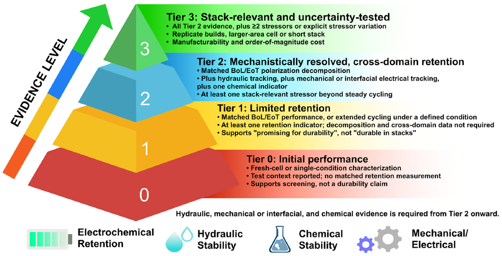

**Representative audit, Table 8:** 22 studies

| Tier 0 | Tier 1 | Tier 2 | Tier 3 |
| --- | --- | --- | --- |
| **6** | **16** | **0** | **0** |

**Review gap**

Earlier reviews did not integrate failure modes, diagnostics and cross-domain durability appraisal.

**Novelty**

A durability-first framework and a proposed evidence rubric, applied to published studies.

**Research gap**

No study in this audit met the complete Tier 2 criteria. Test retained function across domains under matched conditions.

Sondit et al., *J. Power Sources* 694 (2026) 241310. Fig. 2 and Tables 1, 6–8. [DOI: 10.1016/j.jpowsour.2026.241310](https://doi.org/10.1016/j.jpowsour.2026.241310). This is a representative evidence audit, not a PRISMA example.

## Published case: order retention

Our published critical review · Green Chemistry

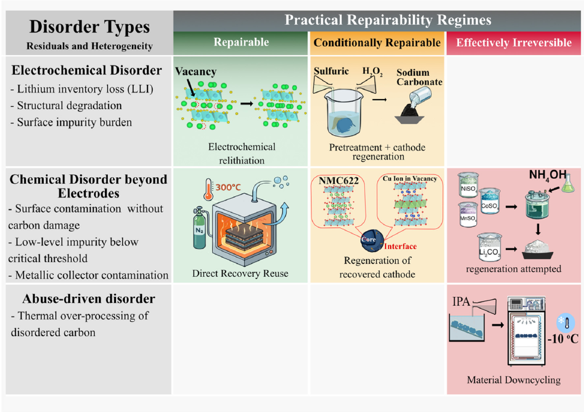

**Review gap**

Recovery yield alone does not explain how much usable material structure survives recycling.

**Novelty**

Order retention links reset depth, repair windows and feedstock condition.

**Research gaps**

Three ledger cells lack reported examples. Proposed thresholds need chemistry-specific calibration and validation.

**Reading the matrix**

Empty cells indicate missing examples, rather than proof of impossible states.

Eeamtak et al., *Green Chemistry* (2026). Fig. 4 and Table 3. [DOI: 10.1039/d6gc03171d](https://doi.org/10.1039/d6gc03171d). Table 3 contains 10 case/condition rows from 8 references. This is a framework and synthesis example, not a PRISMA example.

## Part 5 · Structure and craft

What the finished paper looks like, how to title it, what to budget, and the seven ways it goes wrong.

## The anatomy of a review article

Part 5

1. **Title** — descriptive and specific. It should carry the framework, not just the topic.
2. **Abstract** — a miniature of the whole review, not an introduction to the topic. It must state the main conclusions.
3. **Introduction** — problem, research gap, prior-review gap and planned contribution. State the scope and the years covered, and place the prior-review table here.
4. **Framework** — your taxonomy, tier scheme or conceptual model, defined in its own numbered section before it is used. *Show how it supports your contribution.*
5. **Body** — organised by the framework, never by chronology or by author. One concept per section, a verdict at the end of each.
6. **Cross-cutting** — standards, datasets, scale-up, safety, cost, reproducibility.
7. **Challenges and outlook** — three to five named challenges, each with a specific actionable milestone. *Not “more research is needed”.*
8. **Conclusion** — short. What the field should now believe that it did not believe before.

For a critical review, draft the synthesis framework and evidence-backed outlook early; adapt the structure to the review type.

## Four ways to organise the body

Part 5

### Function-centric

By what the work does: synthesis, characterisation, modelling, deployment. Good when methods differ more than materials do.

### System-oriented

By layer: electrode, electrolyte, interface, cell, pack, system. Good when the field has a natural physical hierarchy.

### Application-driven

By end use: grid storage, transport, portable, off-grid. Good when the same technology faces very different requirements.

### Framework-based

You propose a conceptual framework and organise everything under it. Useful when a new framework explains patterns that existing reviews leave unresolved.

Coherence test: can readers see why each section exists and how it answers the review question? A study may inform several concepts; make the connections explicit.

## The title is the first test of whether you have a thesis

Part 5

Left: could sit on any review of the topic. Right: could only sit on yours.

*“Recent Advances in Zinc-Ion Battery Cathodes”*

*“Why Capacity Fade in Zinc-Ion Cathodes Is a Dissolution Problem, Not a Structural One”*

*“A Review of Machine Learning for Materials Discovery”*

*“Machine Learning for Materials Discovery: Five Benchmarks That Do Not Test Generalisation”*

*“Progress and Perspectives on Solid Electrolytes”*

*“Reported Critical Current Densities in Solid Electrolytes: A Tier-Based Reassessment”*

A title that would fit on any review of the topic is not a title yet. Put the claim, or the framework, into it.

## Budgets, and the three tables that get you cited

Part 5

Rules of thumb

- **~25** references per 1,000 words
- **max 7** display items in a *Nature Reviews*-style Review
- **100–120** references for a comprehensive engineering survey
- **3–5** named challenges in the outlook
- **1** framework, defined once, used everywhere

The three tables

**The prior-review table** — what existed, what it missed, what you add. Editors read it first.

**The evidence table** — every included study, its conditions and its tier. The artefact other authors reuse, and reuse is citation.

**The gap table** — what is not known, why, and what experiment would settle it.

## Seven ways reviews get rejected

Part 5

1. **The laundry list** — one paragraph per paper, joined by “subsequently” and “meanwhile”.
2. **No thesis** — the reader finishes and cannot say what the authors think.
3. **Undefined scope** — no statement of what is included, excluded, or what years are covered.
4. **Cherry-picked evidence** — no selection criteria, so the reader cannot tell what was left out.
5. **Self-citation bloat** — the authors’ own work singled out for emphasis. Referees always notice.
6. **Stale coverage** — the most recent references are two years old, or a newer review already exists.
7. **Generic outlook** — *“Further research is needed.”* This sentence has never helped anyone.

Every one of these is visible in the first two pages. That is where desk rejections happen.

## Exercise 2 · Evidence, gap and contribution

Task 1 · 5 minutes total

Name one evidence pattern and classify the uncertainty: missing, weak, conflicting or hard to transfer.

Task 2

Write the research gap, the next useful study and the new understanding your review could add.

Use Worksheet C in the handout supplement. Mark candidate claims that still need a wider search or comparison with prior reviews.

## Generative AI: what you must disclose in 2026

Part 5

Universal across ACS, RSC, Elsevier, Springer Nature, Wiley, IEEE, ICMJE and COPE

- AI cannot be an author
- Authors remain fully accountable for every sentence and every citation
- Referees must not upload manuscripts to public AI tools
- Grammar and spell checking normally needs no declaration

Specific to review articles

ACS states that editors may reject or require revision where AI use appears excessive, and names generated literature reviews explicitly. Publishers now diverge on whether AI-assisted literature reviews are permitted at all.

The three highest-risk uses are AI-written synthesis prose, AI-suggested citations, and AI-only screening with no human verification.

If you remember three things

1. **A useful review answers a clear question.** Its novelty is the justified understanding it adds beyond prior reviews.
2. **Research gaps need evidence.** Use the matrix to state what remains uncertain, why it matters and what test would help.
3. **Make the path to your conclusion traceable.** Report the search and selection, appraise the evidence and explain your synthesis.

## Questions

Sources and further reading

1. **Typology** — Grant & Booth, *Health Info. Libr. J.* **26**, 91 (2009) · Sutton, Clowes, Preston & Booth, *ibid.* **36**, 202 (2019)
2. **Reporting standards** — PRISMA 2020, PRISMA-ScR and PRISMA-S: prisma-statement.org · JBI Manual: synthesismanual.jbi.global · ROSES: roses-reporting.com
3. **Engineering method** — Kitchenham & Charters, EBSE-2007-01 · Petersen, Vakkalanka & Kuzniarz, *Inf. Softw. Technol.* **64**, 1 (2015) · Niyato et al., arXiv:2509.25828 (2025)
4. **Searching** — Gusenbauer & Haddaway, *Res. Synth. Methods* **11**, 181 (2020) · Gusenbauer & Gauster, *Technol. Forecast. Soc. Change* **212**, 123833 (2025)
5. **Appraisal** — GRADE Handbook: gradepro.org/handbook · Shea et al. (AMSTAR 2), *BMJ* **358**, j4008 (2017)
6. **Craft** — Pautasso, *PLoS Comput. Biol.* **9**, e1003149 (2013) · Webster & Watson, *MIS Quarterly* **26**, xiii (2002) · *Nat. Rev. Bioeng.* **2**, 907 (2024)
7. **Research gaps** — [AHRQ framework](https://www.ncbi.nlm.nih.gov/books/NBK62472/?report=classic): insufficient, biased, inconsistent or inapplicable evidence.
8. **The debate** — Miranda & García-Carpintero (2018) · McMahan & McFarland (2021) · Ioannidis (2016) · Kamat, Christopher & Jin (2025)

Where each colour takes you

1Choose a review type

2Report methods & decisions

3Design an engineering review

4Find & document evidence

5Assess evidence & limitations

6Build argument & novelty

7Justify research gaps

8Weigh review value & risks